# Ambulatory or residential? a multi-state analysis of treatments for substance use disorders (Step 3)

May 24, 2022

# Cumulative Transition Hazards of Joint Models

## Parametric

Cumulative baseline hazard can be estimated non-parametrically through a Breslow estimator. Must take note that we are assuming a semi-markov process in these transitions. The cumulative hazards obtained through the times specified by 183 points. We added the setting at baseline as the first covariate, with the outcome of each treatment as (treatment completion, in 0/1 format) users pass through each transition. Equally, we included the time of arrival as a covariate to each transition (excluding the admission states, because there is no time of arrival).

```r
# Semi-parametric models
#Since there are tied event times, we need to specify ties="breslow" in order to obtain the Aalen-Johansen estimator of
#the transition probability

formula3<-
as.formula(paste0("Surv(time, status) ~", paste0(fitform2," + arrival + strata(trans)")[[3]]))


#_time tipo_de_plan_res_1 TD_1 TD_2 TD_3 TD_4 _start#

formula3_mstate<-
as.formula(paste0("Surv(time, status) ~", paste0(fitform2," + factor(TD_1)+ factor(TD_2)+ factor(TD_3)+ factor(TD_4)+ arrival + strata(trans)")[[3]]))


formula3_mstate_stratified<-
as.formula(paste0("Surv(time, status) ~", paste0(fitform2," + factor(TD_1)+ factor(TD_2)+ factor(TD_3)+ factor(TD_4)+ arrival")[[3]]))

formula3_mstate_stratified_arr<-
as.formula(paste0("Surv(time, status) ~", paste0(fitform2," + factor(TD_1)+ factor(TD_2)+ factor(TD_3)+ factor(TD_4)+ arrival")[[3]]))


#2021-06-03, I changed the regression to Surv(Tstart, Tstop, status) format, but with arrival time.

paste0("For the first transition, we introduced the following Formula: ")
```

```
## [1] "For the first transition, we introduced the following Formula: "
```

```r
formula3_mstate_stratified
```

```
## Surv(time, status) ~ factor(tipo_de_plan_res_1) + factor(TD_1) +
##     factor(TD_2) + factor(TD_3) + factor(TD_4) + arrival
```

```r
paste0("For the second and further transition, we introduced the following Formula: ")
```

```
## [1] "For the second and further transition, we introduced the following Formula: "
```

```r
formula3_mstate_stratified_arr
```

```
## Surv(time, status) ~ factor(tipo_de_plan_res_1) + factor(TD_1) +
##     factor(TD_2) + factor(TD_3) + factor(TD_4) + arrival
```

As seen in the formula above, we included the transition-specific covariables regarding the time that arrived to the state into the models.

```r
fits_c_logn2 <- vector(mode = "list", length = n_trans2)
fits_c_ggam2 <- vector(mode = "list", length = n_trans2)
fits_c_ggam_orig2 <- vector(mode = "list", length = n_trans2)
fits_c_rp022 <- vector(mode = "list", length = n_trans2)
fits_c_rp032 <- vector(mode = "list", length = n_trans2)
fits_c_rp042 <- vector(mode = "list", length = n_trans2)
fits_c_rp052 <- vector(mode = "list", length = n_trans2)

dists_w_covs_5s_w_arrival<-cbind.data.frame(covs=rep("fits_c_",(7*n_trans)),
              formal=rep(c("Generalized gamma", "Generalized gamma (original)", "Lognormal", paste0("RP0",2:5)),1*n_trans2),
              dist=rep(c("gengamma","gengamma.orig", "lnorm", rep("no dist",4)),n_trans2),
              model=rep(c("ggam2", "ggam_orig2", "logn2", paste0("rp0",2:5,2)),1*n_trans2),
              trans=rep(1:n_trans2, each=7))

ms_d_match_surv$arrival<-ms_d_match_surv$Tstart
#APR 2022, had to center the variable to avoid convergence issues
ms_d_match_surv$arrival_cen<-as.numeric(scale(ms_d_match_surv$Tstart, scale = F))
ms_d_match_surv_exp<-mstate::expand.covs(ms_d_match_surv, "TD", append = TRUE, longnames =F)
#ms_d_match_surv_exp$TD<-ms_d_match_surv_res$TD

ms_d_match_surv_res2<-
  #El arrival y el número al lado del arrival repreenta el número de la transición
  mstate::expand.covs(ms_d_match_surv, "TD", append = TRUE, longnames =F)

if(no_mostrar==1){
  ms_d_match_surv %>%
  data.frame() %>%
  dplyr::mutate(tipo_de_plan_res=dplyr::case_when(tipo_de_plan_res_1==1 & trans==1~1,
                                                  tipo_de_plan_res_2==1 & trans==2~1,
                                                  tipo_de_plan_res_3==1 & trans==3~1,
                                                  tipo_de_plan_res_4==1 & trans==4~1,
                                                  T~0)) %>%
    dplyr::mutate(TD=dplyr::case_when(TD_1==1 & trans==1~1,
                                      TD_2==1 & trans==2~1,
                                      TD_3==1 & trans==3~1,
                                      TD_4==1 & trans==4~1,
                                      T~0))
}

#ms_d_match_surv_exp <- expand.covs(ms_d_match_surv_exp, "TD", append = TRUE, longnames =F)

#ms_d_match_surv_exp[is.na(ms_d_match_surv_exp$TD_2),"TD_2"]<-0
#ms_d_match_surv_exp[is.na(ms_d_match_surv_exp$TD_3),"TD_3"]<-0
#ms_d_match_surv_exp[is.na(ms_d_match_surv_exp$TD_4),"TD_4"]<-0

  #mstate::expand.covs(ms_d_match_surv, "arrival", append = TRUE, longnames = FALSE)

#_#_#_#_#_#_#_#_#_#_#_#_#_#_#_#_#_#_#_#_#_#_#_#_#_#_#_#_#_#_#_#_#_#_#_#_#_#_#_#_#_#_
#_#_#_#_#_#_#_#_#_#_#_#_#_#_#_#_#_#_#_#_#_#_#_#_#_#_#_#_#_#_#_#_#_#_#_#_#_#_#_#_#_#_
no_attempts <- 30

fits_cox2<-list()
fits_c_cox2<-list()

form<-
  function(i=1){
  f<-dplyr::case_when(i==4~paste0("Surv(time, status) ~ ",fitform2," + factor(TD_1)+ factor(TD_2)+ factor(TD_3)+ factor(TD_4)+ arrival")[[3]],i==3~paste0("Surv(time, status) ~ ",fitform2," + factor(TD_1)+ factor(TD_2)+ factor(TD_3)+ arrival")[[3]],i==2~paste0("Surv(time, status) ~ ",fitform2," + factor(TD_1)+ factor(TD_2)+ arrival")[[3]],T~paste0("Surv(time, status) ~ ",fitform2," + factor(TD_1)")[[3]])
  return(f)
}

for (i in 1:3){
    r <- NULL
    attempt <- 0
    while( is.null(r) && attempt <= no_attempts ) {
        attempt <- attempt + 1
    try(
      r <- flexsurvreg(formula=as.formula(form(i)),
                             data = subset(dplyr::mutate(ms_d_match_surv_exp,arrival=scale(arrival, scale=F)), trans == i),
                             dist = "gengamma.orig")
        )
    }
    fits_c_ggam_orig2[[i]] <- r
}

for (i in 1:3){
    r <- NULL
    attempt <- 0
    while( is.null(r) && attempt <= no_attempts ) {
      attempt <- attempt + 1
    try(
      r <- flexsurvreg(formula=as.formula(form(i)),
                                   data = subset(dplyr::mutate(ms_d_match_surv_exp,arrival=scale(arrival, scale=F)), trans == i),
                                   dist = "gengamma")
      )
    }
    fits_c_ggam2[[i]] <- r
}

for (i in 4){
    r <- NULL
    attempt <- 0
    while( is.null(r) && attempt <= no_attempts ) {
      attempt <- attempt + 1
    try(
      r <- flexsurvreg(formula=as.formula(form(i)),
                                   data = subset(dplyr::mutate(ms_d_match_surv_exp,arrival=scale(arrival, scale=F)), trans == i),
                                   dist = "lnorm")
      )
    }
    fits_c_logn2[[i]] <- r
}


for (i in 3){
    r <- NULL
    attempt <- 0
    while( is.null(r) && attempt <= no_attempts ) {
      attempt <- attempt + 1
    try(
      r <- flexsurvspline(formula=as.formula(form(i)),
                            k=1,
                               data = subset(ms_d_match_surv_exp, trans == i))
      )
    }
    fits_c_rp022[[i]] <- r
}

for (i in 4){
    r <- NULL
    attempt <- 0
    while( is.null(r) && attempt <= no_attempts ) {
      attempt <- attempt + 1
    try(
      r <- flexsurvspline(formula=as.formula(form(i)),
                            k=2,
                               data = subset(ms_d_match_surv_exp, trans == i))
      )
    }
    fits_c_rp032[[i]] <- r
}

for (i in 2){
    r <- NULL
    attempt <- 0
    while( is.null(r) && attempt <= no_attempts ) {
      attempt <- attempt + 1
    try(
      r <- flexsurvspline(formula=as.formula(form(i)),
                            k=3,
                               data = subset(ms_d_match_surv_exp, trans == i))
      )
    }
    fits_c_rp042[[i]] <- r
}

for (i in 1){
    r <- NULL
    attempt <- 0
    while( is.null(r) && attempt <= no_attempts ) {
      attempt <- attempt + 1
    try(
      r <- flexsurvspline(formula=as.formula(form(i)),
                            k=4,
                               data = subset(ms_d_match_surv_exp, trans == i))
      )
    }
    fits_c_rp052[[i]] <- r
}


#_#_#_#_#_#_#_#_#_#_#_#_#_#_#_#_#_#_#_#_#_#_#_#_#_#_#_#_#_#_#_#_#_#_#_#_#_#_#_#_#_#
#_#_#_#_#_#_#_#_#_#_#_#_#_#_#_#_#_#_#_#_#_#_#_#_#_#_#_#_#_#_#_#_#_#_#_#_#_#_#_#_#_#_
```

```r
  #formula3_mstate_stratified
  #ms_d_match_surv_exp2
```

```
#> ### First fix a patient with reference values for the covariates
#> ### and 0 for all the time-dependent covariates; this will give the
#> ### baseline hazards
```

```r
#_#_#_#_#_#_#_#_#_#_#_#_#_#_#_#_#_#_#_#_#_#_#_#_#_#_#_#_#_#_#_#_#_#_#_#_#_#_
# Database to contrast adjustments
newdat_a <- data.table::data.table(tipo_de_plan_res_1= factor(c(rep(1,1*n_trans2))),
  #comp_status= factor(rep(c("Therapeutic discharge","Discharge without clinical advice"),2)),
  TD_1=rep(0,),
  TD_2=rep(0,),
  TD_3=rep(0,),
  TD_4=rep(0,),
  arrival=rep(0,),
  strata= rep(1:n_trans2,1)
                       )
newdat_b <- data.table::data.table(tipo_de_plan_res_1= factor(c(rep(0,1*n_trans2))),
  #comp_status= factor(rep(c("Therapeutic discharge","Discharge without clinical advice"),2)),
  TD_1=rep(0,),
  TD_2=rep(0,),
  TD_3=rep(0,),
  TD_4=rep(0,),
  arrival=rep(0,),
  strata= rep(1:n_trans2,1)
                       )

#_#_#_#_#_#_#_#_#_#_#_#_#_#_#_#_#_#_#_#_#_#_#_#_#_#_#_#_#_#_#_#_#_#_#_#_#_#_#_#_#_#_
#_#_#_#_#_#_#_#_#_#_#_#_#_#_#_#_#_#_#_#_#_#_#_#_#_#_#_#_#_#_#_#_#_#_#_#_#_#_#_#_#_#_
#APR 2022- SCALING
newdat_a_sc<-mutate(newdat_a,arrival=scale(1096-attr(scale(ms_d_match_surv_exp$arrival,scale=F),"scaled:center"),scale=F))
newdat_b_sc<-mutate(newdat_b,arrival=scale(1096-attr(scale(ms_d_match_surv_exp$arrival,scale=F),"scaled:center"),scale=F))
newdat_a$arrival<-ifelse(newdat_a$arrival==0,1096,newdat_a$arrival)
newdat_b$arrival<-ifelse(newdat_b$arrival==0,1096,newdat_b$arrival)

#_#_#_#_#_#_#_#_#_#_#_#_#_#_#_#_#_#_#_#_#_#_#_#_#_#_#_#_#_#_#_#_#_#_#_#_#_#_#_#_#_#_
#_#_#_#_#_#_#_#_#_#_#_#_#_#_#_#_#_#_#_#_#_#_#_#_#_#_#_#_#_#_#_#_#_#_#_#_#_#_#_#_#_#_

fitted_flexsurvreg2<-data.frame()
fit_flexsurvreg2<-data.frame()

dists_w_covs_5s_w_arrival<-dists_w_covs_5s_w_arrival %>%
  dplyr::filter(model %in% c(paste0("rp0",2:5,"2"),"ggam2","logn2")) %>%
  dplyr::filter(dplyr::case_when(model=="logn2" & trans==4~T,
                                 model=="ggam2" & trans %in% 1:3~T,
                                 model=="rp032" & trans==4~T,
                                 model=="rp052" & trans==1~T,
                                 model=="rp042" & trans==2~T,
                                 model=="rp022" & trans==3~T,
                                 T~F)) %>%
  dplyr::mutate(get_nd_a=dplyr::case_when(grepl("rp",model)~"newdat_a",T~"newdat_a_sc")) %>%
  dplyr::mutate(get_nd_b=dplyr::case_when(grepl("rp",model)~"newdat_b",T~"newdat_b_sc"))
#
for (i in nrow(dists_w_covs_5s_w_arrival)){  #

  cat(paste0("#### Flexible Survival Model (w/ covs): ",
               dists_w_covs_5s_w_arrival[i,"formal"], "; transition: ",dists_w_covs_5s_w_arrival[i,"trans"], "\n \n"))

  model<-paste0("fits_c_",dists_w_covs_5s_w_arrival[i,"model"])
  nd_a<-get(dists_w_covs_5s_w_arrival[i,"get_nd_a"])
  nd_b<-get(dists_w_covs_5s_w_arrival[i,"get_nd_b"])

  invisible(c("Real"))
  tryCatch(
    if(!is.null(get(model)[[dists_w_covs_5s_w_arrival[i,"trans"]]])){
    #Generate databases
     fitted_flexsurvreg2<- dplyr::bind_rows(fitted_flexsurvreg2,cbind.data.frame(dist=rep(dists_w_covs_5s_w_arrival[i,"formal"],),
                                trans=rep(dists_w_covs_5s_w_arrival[i,"trans"],),
                                residential=rep(1,),
                                data.table::data.table(summary(get(model)[[dists_w_covs_5s_w_arrival[i,"trans"]]], newdata= nd_a, newtime=unique(fitted_km$time), type = "survival", tidy=T))))
      fitted_flexsurvreg2<- dplyr::bind_rows(fitted_flexsurvreg2,cbind.data.frame(dist=rep(dists_w_covs_5s_w_arrival[i,"formal"],),
                                trans=rep(dists_w_covs_5s_w_arrival[i,"trans"],),
                                residential=rep(0,),
                                data.table::data.table(summary(get(model)[[dists_w_covs_5s_w_arrival[i,"trans"]]], newdata= nd_b,  newtime=unique(fitted_km$time), type = "survival", tidy=T))))
     #t=newtime0,
      # Generate fit indices
      fit_flexsurvreg2<-rbind(fit_flexsurvreg2,
         cbind(dist= dists_w_covs_5s_w_arrival[i,"formal"],
               transition=dists_w_covs_5s_w_arrival[i,"trans"],
               fitstats.flexsurvreg(get(model)[[dists_w_covs_5s_w_arrival[i,"trans"]]])))
      #the BIC may not be appropriate if none of the candidate models are considered to be close to the ‘true’ model.
      } else {
      cat(paste0("The model that assumed a ",dists_w_covs_5s_w_arrival[i,"formal"]," distribution for the transition number ",dists_w_covs_5s_w_arrival[i,"trans"]," did not converge \n\n"))
      }, error=function(e) {
        cat(paste0("The model that assumed a ",dists_w_covs_5s_w_arrival[i,"formal"]," distribution for the transition number ",dists_w_covs_5s_w_arrival[i,"trans"]," did not converge (empty) \n\n"))
    })
}
```

```
## #### Flexible Survival Model (w/ covs): RP03; transition: 4
##
```

```r
fit_flexsurvreg22<-
  fit_flexsurvreg2 %>%
  data.frame() %>%
  dplyr::mutate(across(c("n2ll", "AIC", "AICc", "BIC"),~as.numeric(ifelse(abs(.)>1e7,NA,format(round(.,2), scientific = FALSE))))) %>%
  data.frame()
#Generalized gamma  RP03/Lognormal RP02/Lognormal  Generalized F/RP02
# fits_c_ggam2 fits_c_rp032/fits_c_logn2 fits_c_rp022/fits_c_logn2 fits_c_genf2/fits_c_rp022

distribution_by_trans_valid_cis<-
fitted_flexsurvreg2 %>%
    dplyr::filter(!is.na(lcl)) %>%
    group_by(trans) %>% distinct(dist)
invisible(c("No hay intervalos de confianza en TDs "))
```

```r
invisible(c("Intercept-only"))
fitted_flexsurvreg_binned_mix0 %>%
    dplyr::mutate(abs((est-surv)/surv)) %>% group_by(dist,trans) %>% dplyr::mutate(cumsum_error=cumsum(`abs((est - surv)/surv)`)) %>%
    group_by(trans) %>%
    dplyr::slice_max(time) %>%
    mutate(rank = dense_rank(cumsum_error)) %>%
    dplyr::ungroup() %>%
    dplyr::arrange(trans,rank) %>%
    dplyr::select(dist, trans, time, lcl, cumsum_error,rank) %>%
    copiar_nombres()

fitted_flexsurvreg_binned_mix0 %>%
    dplyr::mutate(abs((est-surv)/surv)) %>% group_by(dist,trans) %>% dplyr::mutate(cumsum_error=cumsum(`abs((est - surv)/surv)`)) %>%
    dplyr::filter(time>=365.25*3) %>%
    group_by(trans) %>%
    dplyr::slice_min(time) %>%
    mutate(rank = dense_rank(cumsum_error)) %>%
    dplyr::ungroup() %>%
    dplyr::arrange(trans,rank) %>%
    dplyr::select(dist, trans, time, lcl, cumsum_error,rank) %>%
    copiar_nombres()
#_#_:#_:#_:#_:#_:#_:#_:#_:#_:#_:#_:#_#_:#_:#_:#_:#_:#_:#_:#_:#_:#_:#_:
#_#_:#_:#_:#_:#_:#_:#_:#_:#_:#_:#_:#_#_:#_:#_:#_:#_:#_:#_:#_:#_:#_:#_:

fitted_flexsurvreg %>%
    dplyr::left_join(fitted_km, by=c("time", "trans", "residential")) %>%
    group_by(trans,dist,residential) %>%
    tidyr::fill(surv,.direction="down") %>%
    ungroup() %>%
    dplyr::mutate(abs((est-surv)/surv)) %>%
    group_by(trans,dist,residential) %>%
    dplyr::mutate(cumsum_error=cumsum(replace_na(`abs((est - surv)/surv)`, 0))) %>%
    dplyr::ungroup() %>%
    group_by(trans, residential) %>%
    dplyr::slice_max(time) %>%
    mutate(rank = dense_rank(cumsum_error)) %>%
    dplyr::ungroup() %>%
    dplyr::arrange(trans,rank) %>%
    dplyr::select(dist, trans, residential,time, lcl, cumsum_error,rank) %>%
    dplyr::filter(residential==1) %>%
    copiar_nombres()

fitted_flexsurvreg %>%
    dplyr::left_join(fitted_km, by=c("time", "trans", "residential")) %>%
    group_by(trans,dist,residential) %>%
    tidyr::fill(surv,.direction="down") %>%
    ungroup() %>%
    dplyr::mutate(abs((est-surv)/surv)) %>%
    group_by(trans,dist,residential) %>%
    dplyr::mutate(cumsum_error=cumsum(replace_na(`abs((est - surv)/surv)`, 0))) %>%
    dplyr::ungroup() %>%
    group_by(trans, residential) %>%
    dplyr::slice_max(time) %>%
    mutate(rank = dense_rank(cumsum_error)) %>%
    dplyr::ungroup() %>%
    dplyr::arrange(trans,rank) %>%
    dplyr::select(dist, trans, residential,time, lcl, cumsum_error,rank) %>%
    dplyr::filter(residential==0) %>%
    copiar_nombres()


fitted_flexsurvreg %>%
    dplyr::left_join(fitted_km, by=c("time", "trans", "residential")) %>%
    group_by(trans,dist,residential) %>%
    tidyr::fill(surv,.direction="down") %>%
    ungroup() %>%
    dplyr::mutate(abs((est-surv)/surv)) %>%
    group_by(trans,dist,residential) %>%
    dplyr::mutate(cumsum_error=cumsum(replace_na(`abs((est - surv)/surv)`, 0))) %>%
    dplyr::ungroup() %>%
    dplyr::filter(time>=365.25*3) %>%
    group_by(trans, residential) %>%
    dplyr::slice_min(time) %>%
    mutate(rank = dense_rank(cumsum_error)) %>%
    dplyr::ungroup() %>%
    dplyr::arrange(trans,rank) %>%
    dplyr::select(dist, trans, residential,time, lcl, cumsum_error,rank) %>%
    dplyr::filter(residential==1) %>%
    copiar_nombres()

fitted_flexsurvreg %>%
    dplyr::left_join(fitted_km, by=c("time", "trans", "residential")) %>%
    group_by(trans,dist,residential) %>%
    tidyr::fill(surv,.direction="down") %>%
    ungroup() %>%
    dplyr::mutate(abs((est-surv)/surv)) %>%
    group_by(trans,dist,residential) %>%
    dplyr::mutate(cumsum_error=cumsum(replace_na(`abs((est - surv)/surv)`, 0))) %>%
    dplyr::ungroup() %>%
    dplyr::filter(time>=365.25*3) %>%
    group_by(trans, residential) %>%
    dplyr::slice_min(time) %>%
    mutate(rank = dense_rank(cumsum_error)) %>%
    dplyr::ungroup() %>%
    dplyr::arrange(trans,rank) %>%
    dplyr::select(dist, trans, residential,time, lcl, cumsum_error,rank) %>%
    dplyr::filter(residential==0) %>%
    copiar_nombres()
```

## Cox

```r
# Semi-parametric models
#Since there are tied event times, we need to specify ties="breslow" in order to obtain the Aalen-Johansen estimator of
#the transition probability

#_#_#_#_#_#_#_#_#_#_#_#_#_#_#_#_#_#_#_#_#_#_#_#_#_#_#_#_#_#_#_#_#_#_#_#_#_#_#_#_
#_#_#_#_#_#_#_#_#_#_#_#_#_#_#_#_#_#_#_#_#_#_#_#_#_#_#_#_#_#_#_#_#_#_#_#_#_#_#_#_

cox_fits <- survival::coxph(formula3_mstate,
                            data = ms_d_match_surv_exp, method = "breslow")

paste0("Test the Proportional Hazards Assumption of a Cox Regression:")
```

```
## [1] "Test the Proportional Hazards Assumption of a Cox Regression:"
```

```r
cox.zph(cox_fits)
```

```
##                            chisq df       p
## factor(tipo_de_plan_res_1)  0.27  1   0.604
## factor(TD_1)               24.82  1 6.3e-07
## factor(TD_2)                4.05  1   0.044
## factor(TD_3)                5.13  1   0.024
## factor(TD_4)                1.75  1   0.186
## arrival                    25.19  1 5.2e-07
## GLOBAL                     50.78  6 3.3e-09
```

```r
paste0(c("Not-proportional hazards"))
```

```
## [1] "Not-proportional hazards"
```

```r
# fits_c_ggam2 fits_c_rp032/fits_c_logn2 fits_c_rp022/fits_c_logn2 fits_c_genf2/fits_c_rp022
#dists_w_covs_5s_w_arrival

invisible(c("dists_w_covs_5s_w_arrival ver para ver la distribución"))
#1° TRANS, un modelo con splines cúblicos restringidos a 4 nudos (RP05) y la distribución F generalizado (después G-gamma en STATA) obtuvieron un mejor ajuste. En R, el único que Gen-F es peor que RP
#2° TRANS, un modelo con splines cúblicos restringidos a 3 nudos (RP04) y la distribución F generalizado (después G-gamma en STATA) obtuvieron un mejor ajuste.
#3° TRANS, un modelo con splines cúblicos restringidos a 2 nudos (RP03) y la distribución F generalizado (Lognormal en STATA) obtuvieron un mejor ajuste.
#4° TRANS, un modelo con splines cúblicos restringidos a 2 nudos (RP03) y la distribución F generalizado (Lognormal en STATA) obtuvieron un mejor ajuste.
#EN STATA, todos los RPs son mejores que los paramétricos. En R, sólo la transición 3 y 4 tienen menor error en  Gen-F en el max time
sel_param_fits_a <- vector(length = n_trans, mode = "list")
    sel_param_fits_a[[1]]<- fits_c_ggam2[[1]] #fits_c_genf2[[1]]
    sel_param_fits_a[[2]]<- fits_c_ggam2[[2]]
    sel_param_fits_a[[3]]<- fits_c_ggam2[[3]] #Porque gen gamma y gen gamma original no convergen
    sel_param_fits_a[[4]]<- fits_c_logn2[[4]] #Porque gen gamma y gen f no convergen

sel_param_fits_b <- vector(length = n_trans, mode = "list")
    sel_param_fits_b[[1]]<- fits_c_rp052[[1]]
    sel_param_fits_b[[2]]<- fits_c_rp042[[2]]
    sel_param_fits_b[[3]]<- fits_c_rp022[[3]]
    sel_param_fits_b[[4]]<- fits_c_rp032[[4]]
```

```r
#https://stats.stackexchange.com/questions/533495/can-one-compare-hazard-ratio-and-average-hazard-ratio?noredirect=1&lq=1

# Probability Density Functions
f0 <- function(x,
               mu = coef(fits_c_ggam2[[1]])["mu"],
               sigma =exp(coef(fits_c_ggam2[[1]])["sigma"]),
               Q = coef(fits_c_ggam2[[1]])["Q"]){
  dgengamma(x=x, mu=mu, sigma=sigma, Q=Q)
}
f1 <- function(x,
               mu = coef(fits_c_ggam2[[1]])["mu"]+coef(fits_c_ggam2[[1]])["factor(tipo_de_plan_res_1)1"],
               sigma =exp(coef(fits_c_ggam2[[1]])["sigma"]),
               Q = coef(fits_c_ggam2[[1]])["Q"]){
  dgengamma(x=x, mu=mu, sigma=sigma, Q=Q)
}
ft <- function(x){ (f0(x) + f1(x))}
# Cumulative Density Functions
S0 <- function(x,
               mu = coef(fits_c_ggam2[[1]])["mu"],
               sigma =exp(coef(fits_c_ggam2[[1]])["sigma"]),
               Q = coef(fits_c_ggam2[[1]])["Q"]){
  pgengamma(q=x, mu=mu, sigma=sigma, Q=Q, lower=FALSE)
}
S1 <- function(x,
               mu = coef(fits_c_ggam2[[1]])["mu"]+coef(fits_c_ggam2[[1]])["factor(tipo_de_plan_res_1)1"],
               sigma =exp(coef(fits_c_ggam2[[1]])["sigma"]),
               Q = coef(fits_c_ggam2[[1]])["Q"]){
  pgengamma(q=x, mu=mu, sigma=sigma, Q=Q, lower=FALSE)
}
St <- function(x){ ( S0(x) * f0(x) + S1(x) * f1(x) ) / ( f0(x) + f1(x) ) }
## St <- function(x){ (S0(x) + S1(x))/2} ## assuming same number of events
## Hazard functions
h0 <- function(x,
               mu = coef(fits_c_ggam2[[1]])["mu"],
               sigma =exp(coef(fits_c_ggam2[[1]])["sigma"]),
               Q = coef(fits_c_ggam2[[1]])["Q"]){
  hgengamma(x=x, mu=mu, sigma=sigma, Q=Q)
}
h1 <- function(x,
               mu = coef(fits_c_ggam2[[1]])["mu"]+coef(fits_c_ggam2[[1]])["factor(tipo_de_plan_res_1)1"],
               sigma =exp(coef(fits_c_ggam2[[1]])["sigma"]),
               Q = coef(fits_c_ggam2[[1]])["Q"]){
  hgengamma(x=x, mu=mu, sigma=sigma, Q=Q)
}
#The sAHR [Schemper et al., 2009] is intuitive, but not symmetric in h0(t) and h1(t) and therefore not recommended
calcAHRsmp <- function(x, h0, h1, ft, wt){
  integrand <- function(x){h1(x)/h0(x) * wt(x) * ft(x) }
  ahr <- integrate(integrand, lower=0, upper=x)$value
  return(ahr)
}
#The gAHR [Schemper et al., 2009] does not suffer from the disadvantages of the sAHR, but represents a geometric average hazard ratio.
calcAHRgeo <- function(x, h0, h1, ft, wt){
  integrand <- function(x){ log(h1(x)/h0(x)) * wt(x) * ft(x) }
  logahr <- integrate(integrand, lower=0, upper=x)$value
  ahr <- exp(logahr)
  return(ahr)
}
calcAHRoc <- function(x, f0, f1, S0, S1){
  integrand1 <- function(x){S0(x) * f1(x)}
  term1 <- integrate(integrand1, lower=0, upper=x)$value
  integrand2 <- function(x){S1(x) * f0(x)}
  term2 <- integrate(integrand2, lower=0, upper=x)$value
  ahr <- term1 / term2
  return(ahr)
}
sahr.maxt25p <- calcAHRsmp(x=max(subset(ms_d_match_surv_exp, trans==1)$time)/4, h0=h0, h1=h1, ft=ft, wt=St)
print(sahr.maxt25p)
```

```
## [1] 0.7562758
```

```r
## sAHR for max/2 FU period (50%)
sahr.maxt50p <- calcAHRsmp(x=max(subset(ms_d_match_surv_exp, trans==1)$time)/2, h0=h0, h1=h1, ft=ft, wt=St)
print(sahr.maxt50p)
```

```
## [1] 0.9171241
```

```r
## [1] 0.1131397
## gAHR for max FU period (100%)
sahr.maxt100p <- calcAHRsmp(x=max(subset(ms_d_match_surv_exp, trans==1)$time), h0=h0, h1=h1, ft=ft, wt=St)
print(sahr.maxt100p)
```

```
## [1] 1.046832
```

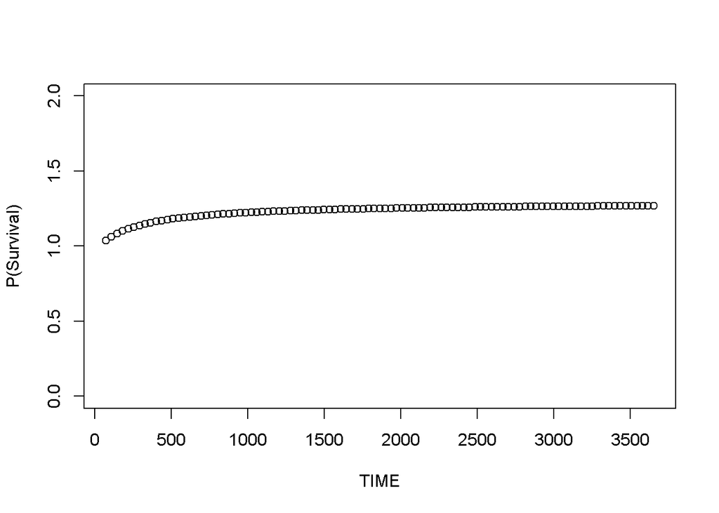

```r
## [1] 0.2209214

ff <- function(x){calcAHRgeo(x=x, h0=h0, h1=h1, ft=ft, wt=St)}
tt <- seq(0.2*365.25,10*365.25,0.1*365.25)
yy <- sapply(tt, FUN=ff)
plot(tt, yy, ylim=c(0,2), xlab="TIME", ylab="P(Survival)")
```

```r
ocahr.maxt3m <- calcAHRoc(x=90, f0=f0, f1=f1, S0=S0, S1=S1)

ocahr.maxt1yr <- calcAHRoc(x=365.25, f0=f0, f1=f1, S0=S0, S1=S1)

ocahr.maxt3yr <- calcAHRoc(x=365.25*3, f0=f0, f1=f1, S0=S0, S1=S1)

ocahr.maxt5yr <- calcAHRoc(x=365.25*5, f0=f0, f1=f1, S0=S0, S1=S1)

ahr.maxt3m <- calcAHRgeo(x=90, h0=h0, h1=h1, ft=ft, wt=St)

ahr.maxt1yr <- calcAHRgeo(x=365.25, h0=h0, h1=h1, ft=ft, wt=St)

ahr.maxt3yr <- calcAHRgeo(x=365.25*3, h0=h0, h1=h1, ft=ft, wt=St)

ahr.maxt5yr <- calcAHRgeo(x=365.25*5, h0=h0, h1=h1, ft=ft, wt=St)

#aHR
print("Average hazard ratio")
```

```
## [1] "Average hazard ratio"
```

```r
cat("The average HR (residential:outpatient) for patients with a follow-up period of",
    "3 months",
    "\nthe average hazard ratio is ",
    round(ahr.maxt3m, 2), ".")
```

```
## The average HR (residential:outpatient) for patients with a follow-up period of 3 months
## the average hazard ratio is  1.05 .
```

```r
cat("The average HR (residential:outpatient) for patients with a follow-up period of",
     "one year",
    "\nthe average hazard ratio is ",
    round(ahr.maxt1yr, 2), ".")
```

```
## The average HR (residential:outpatient) for patients with a follow-up period of one year
## the average hazard ratio is  1.16 .
```

```r
cat("The average HR (residential:outpatient) for patients with a follow-up period of",
    "three years",
    "\nthe average hazard ratio is ",
    round(ahr.maxt3yr, 2), ".")
```

```
## The average HR (residential:outpatient) for patients with a follow-up period of three years
## the average hazard ratio is  1.23 .
```

```r
cat("The average HR (residential:outpatient) for patients with a follow-up period of",
    "five years",
    "\nthe average hazard ratio is ",
    round(ahr.maxt5yr, 2), ".")
```

```
## The average HR (residential:outpatient) for patients with a follow-up period of five years
## the average hazard ratio is  1.25 .
```

```r
#The OC is the probability P(T1 < T0) that a randomly chosen survival time T1 from group G1 is smaller than a randomly
#chosen survival time T0 from group G0.

# The concordance probability represents the pairwise probability of lower patient risk given longer survival time. The c-index and the concordance probability estimate have been used to estimate the concordance probability when patient-specific risk scores are continuous.
# average HRs which them selves approximate the odds of concordance, defined for two treatment groups A and B as OC = P(TA < TB)/P(TB < TA), where TA and TB denote survival times from two subjects randomly selected from these groups. Odds of concordance can be conveniently transformed into concordance probabilities c = P(TA < TB) = OC/(OC + 1), which are intuitive effect size measures
# probabilidad de que grupo B[ambulatorio] tenga >T que A[residencial]
# /probabilidad de que grupo A[residencial] tenga >T que B[ambulatorio]
# AHR (average hazard ratio) setting, the weight for all cases at risk at an event time t is set to the product of the estimated survival probability and the inverse of the estimated probability of censoring at that time.
# AHR: La ponderación por cada tiempo evento t es= p(supervivencia)* 1/p(censura|t)
print("Odds of concordance")
```

```
## [1] "Odds of concordance"
```

```r
cat("The average HR (residential:outpatient) for patients with a follow-up period of",
    "3 months",
    "\nthe average hazard ratio (odds of concordance) is ",
    round(ocahr.maxt3m, 4), ".")
```

```
## The average HR (residential:outpatient) for patients with a follow-up period of 3 months
## the average hazard ratio (odds of concordance) is  3.2772 .
```

```r
cat("The average HR (residential:outpatient) for patients with a follow-up period of",
     "one year",
    "\nthe average hazard ratio (odds of concordance) is ",
    round(ocahr.maxt1yr, 4), ".")
```

```
## The average HR (residential:outpatient) for patients with a follow-up period of one year
## the average hazard ratio (odds of concordance) is  1.922 .
```

```r
cat("The average HR (residential:outpatient) for patients with a follow-up period of",
    "three years",
    "\nthe average hazard ratio (odds of concordance) is ",
    round(ocahr.maxt3yr, 4), ".")
```

```
## The average HR (residential:outpatient) for patients with a follow-up period of three years
## the average hazard ratio (odds of concordance) is  1.5783 .
```

```r
cat("The average HR (residential:outpatient) for patients with a follow-up period of",
    "five years",
    "\nthe average hazard ratio (odds of concordance) is ",
    round(ocahr.maxt5yr, 4), ".")
```

```
## The average HR (residential:outpatient) for patients with a follow-up period of five years
## the average hazard ratio (odds of concordance) is  1.4929 .
```

```r
#Example by https://www.ncbi.nlm.nih.gov/pmc/articles/PMC5868723/
#library(mstate)
# Semi-parametric
cox_cumhaz_a <- mstate::msfit(cox_fits,
                            newdata = newdat_a,
                            trans = trans_matrix, variance = T)
cox_cumhaz_b <- mstate::msfit(cox_fits,
                            newdata = newdat_b,
                            trans = trans_matrix, variance = T)
```

```r
#
#https://rdrr.io/cran/flexsurv/man/msfit.flexsurvreg.html
# Parametric
#scale(ms_d_match_surv_exp$arrival,scale=F)
flexsurv_cumhaz_a <- flexsurv::msfit.flexsurvreg(sel_param_fits_a,#sel_param_fits,
                                             newdata = newdat_a_sc,
                                             t = seq(90, 1827, length.out= 183),
                                             #B = n_iter/50,
                                             trans = trans_matrix, variance = F)

invisible(c("Not allowed to include variance =T : Error in boot[, , i] <- if (is.flexsurvlist(object)) normbootfn.flexsurvreg(object[[i]],  :
  number of items to replace is not a multiple of replacement length"))

flexsurv_cumhaz_b <- flexsurv::msfit.flexsurvreg(sel_param_fits_a,#sel_param_fits_4s_b,#sel_param_fits_4s, #Alternatively, if the parameters (including covariate effects) are assumed to be different between different transitions, then a list of transition-specific models can be formed. This list has one component for each permitted transition in the multi-state model. This is more computationally efficient, particularly for larger models and datasets. See the example below, and the vignette.
                                             newdata = newdat_b_sc, #A data frame specifying the values of covariates in the fitted model, other than the transition number. This must be specified if there are other covariates. The variable names should be the same as those in the fitted model formula. There must be either one value per covariate (the typical situation) or n values per covariate, a different one for each of the n allowed transitions.
                                             t = seq(90, 1827, length.out= 183), #Vector of times. These do not need to be the same as the observed event times, and since the model is parametric, they can be outside the range of the data. A grid of more frequent times will provide a better approximation to the cumulative hazard trajectory for prediction with probtrans or mssample, at the cost of greater computational expense.
                                             #B = n_iter/20,#Number of simulations from the normal asymptotic distribution used to calculate variances. Decrease for greater speed at the expense of accuracy.
                                             trans = trans_matrix,
                                             variance = F)#Calculate the variances and covariances of the transition cumulative hazards (TRUE or FALSE). This is based on simulation from the normal asymptotic distribution of the estimates, which is computationally-expensive.


flexsurv_cumhaz_rp_a <- flexsurv::msfit.flexsurvreg(sel_param_fits_b,#sel_param_fits,
                                             newdata = newdat_a,
                                             t = seq(90, 1827, length.out= 183),
                                             B = n_iter/20,
                                             trans = trans_matrix, variance = F)


flexsurv_cumhaz_rp_b <- flexsurv::msfit.flexsurvreg(sel_param_fits_b,#sel_param_fits,
                                             newdata = newdat_b,
                                             t = seq(90, 1827, length.out= 183),
                                             #B = n_iter/20,
                                             trans = trans_matrix, variance = F)
```

```r
trans_lab_four_st<-
cbind.data.frame(transition_label,trans_nmb=sprintf("%02d",1:n_trans2)) %>%
    dplyr::mutate(paste=paste0(trans_nmb,") ",transition_label))
trans_lab_four_st_vec<-trans_lab_four_st$paste
attr(trans_lab_four_st_vec, "names")<-1:max(trans_matrix,na.rm=t)
#seq(90, 1827, length.out= 183)

#msf1 tipo de plan 1 ==1
#msf0 tipo de plan 1 ==0
cumhaz_data_a <- rbind(data.frame(msf1$Haz[msf1$Haz$time<=1827,],
                                model = "NP Cox"),
                      data.frame(cox_cumhaz_a$Haz,
                                model = "Cox"),
                      data.frame(flexsurv_cumhaz_a$Haz,
                                model = "Parametric"),
                      data.frame(flexsurv_cumhaz_rp_a$Haz,
                                model = "Parametric (RP)"))
cumhaz_data_a$trans <- factor(cumhaz_data_a$trans,
                            levels = seq(1, 4),
                            labels = trans_lab_four_st$paste)
cumhaz_data_b <- rbind(data.frame(msf0$Haz[msf0$Haz$time<=1827,],
                                model = "NP Cox"),
                      data.frame(cox_cumhaz_b$Haz,
                                model = "Cox"),
                      data.frame(flexsurv_cumhaz_b$Haz,
                                model = "Parametric"),
                      data.frame(flexsurv_cumhaz_rp_b$Haz,
                                model = "Parametric (RP)"))
cumhaz_data_b$trans <- factor(cumhaz_data_b$trans,
                            levels = seq(1, 4),
                            labels = trans_lab_four_st$paste)
```

## Plots

```r
#states_trans_lab
fig_diff_mod_ab<-
ggplot()+
  geom_step(data=reshape2::melt(cumhaz_data_a,id.vars=c("time","trans","model"))%>% dplyr::filter(model!="Cox"), aes(time, value, color= model,linetype="dashed"),size=1, alpha=.65) +
  geom_step(data=reshape2::melt(cumhaz_data_b,id.vars=c("time","trans","model"))%>% dplyr::filter(model!="Cox"), aes(time, value, color= model,linetype="solid"),size=1, alpha=.65) +
  facet_wrap(trans~., ncol=1, scales="free_y") +
  scale_color_manual(name ="Model",values=c("#e66101","#fdb863","#b2abd2", "#5e3c99"),labels= c("NP Cox","Par","Par(RP)"))+
  #"Cox",
  scale_linetype_manual(name= "Setting",values=c("dashed","solid"), labels=c("Residential","Ambulatory"))+ #dashed, a; solid, b
  scale_x_continuous(breaks=seq(0, 365.25*5, by = 365.25), labels=seq(0, 5, by = 1), minor_breaks = seq(0, 365.25*5, by = 365.25*.5))+
  xlab("Years") +
  ylab("Cumulative hazards") +
  theme_minimal()+
  theme(legend.position=c(.9,.59),
        legend.background = element_rect(fill="white",
                                  size=0.5, linetype="solid",
                                  colour ="black"))

if(no_mostrar==1){
jpeg(paste0(gsub("SUD_CL","_mult_state_ags/",path),"cum_haz_pat1_apr22.jpg"), height=30, width= 10, res= 600, units = "in")
fig_diff_mod_ab
  dev.off()
}
```

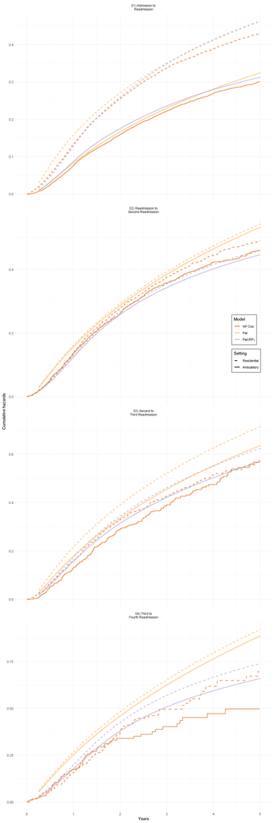

Figure 1b. Estimate of Cumulative Hazards, Five States Model, 1st Patient

```r
fig_diff_mod_ab+ theme(legend.position=c(.9,.585))
```

# Transition Probabilites of the Multistate Model

For mstate package, it is possible to use simulation to calculate transition probabilities through `mssample`.

In semi-Markov models, solving the Kolmogorov forward equation numerically is not feasible because the transition is no longer a deterministic function of t, depending on the transition history to estimate differences. Considering the abovementioned, we calculated the transition probabilities not through a deterministic approach, but following a probabilistic one through resamples.

The cumulative hazards obtained are used to simulate the times at which patients transition between health states, that is, state occupancy probabilities with a “clock-reset” model.

```r
n_iter<-n_iter/10#es 10,000 pero podría bajarlo a /200 como prueba
n_M = 1e5 #format(1e5, scientific=F)

time_before_transprob<-Sys.time()

for(i in c(90,365,1096,1827)){
  set.seed(1234)
  flexsurv::pmatrix.simfs(x = sel_param_fits_a,
                        t = i, #Must be a single number unlike pmatrix.fs
                        ci = T,
                        B= n_iter/10, #Increasing B is usually more expensive than increasing M. NUmber of simulations from the normal asymptotic distribution. MOre, more accuracy
                        newdat= newdat_a_sc,
                        tvar="trans",
                        #tcovs= "arrival",# Predicatable time-dependent covariates such as age
                        cores= 6,
                        M =n_M,#Number of individual trajectories to simulate.
                        trans = trans_matrix) %>%
  assign(paste0("pmatrix1_t_a_",i),.,envir=.GlobalEnv)
}

for(i in c(90,365,1096,1827)){
  set.seed(2125)
  flexsurv::pmatrix.simfs(x = sel_param_fits_a,
                        t = i, #Must be a single number unlike pmatrix.fs
                        ci = T,
                        B= n_iter/10,
                        newdat= newdat_b_sc,
                        tvar="trans",
                        #tcovs= "arrival",# Predicatable time-dependent covariates such as age
                        cores= 6,
                        M =  n_M,#Number of individual trajectories to simulate.
                        trans = trans_matrix) %>%
  assign(paste0("pmatrix1_t_b_",i),.,envir=.GlobalEnv)
}

for(i in c(90,365,1096,1827)){
  set.seed(2125)
  flexsurv::pmatrix.simfs(x = sel_param_fits_b,
                        t = i,
                        ci = T,
                        B= n_iter/10,
                        newdat= newdat_a,
                        tvar="trans",
                        #tcovs= "arrival",
                        M =  n_M,#Number of individual trajectories to simulate.
                        cores= 6,#N of processor cores
                        trans = trans_matrix) %>%
  assign(paste0("pmatrix1_t_rp_a_",i),.,envir=.GlobalEnv)
}

for(i in c(90,365,1096,1827)){
  set.seed(1234)
  flexsurv::pmatrix.simfs(x = sel_param_fits_b,
                        t = i,
                        ci = T,
                        B= n_iter/10,
                        newdat= newdat_b,
                        tvar="trans",
                        #tcovs= "arrival",
                        M = n_M,#Number of individual trajectories to simulate.
                        cores= 6,#N of processor cores
                        trans = trans_matrix) %>%
  assign(paste0("pmatrix1_t_rp_b_",i),.,envir=.GlobalEnv)
}

time_after_transprob<-Sys.time()

paste0("Time in process: ");time_after_transprob-time_before_transprob
```

```
## [1] "Time in process: "
```

```
## Time difference of 2.53365 hours
```

# Length of Stay

```r
time_before_los<-Sys.time()

for(i in c(90,365,1096,1827)){
set.seed(2125)
flexsurv::totlos.simfs(sel_param_fits_a,
             t = i, #Maximum time to predict to.
            # start = 1, #Starting state.
             newdata = newdat_a_sc,
             trans= trans_matrix,
             ci = T, #Return a confidence interval calculated by simulating from the asymptotic normal distribution of the maximum likelihood estimates. This is turned off by default, since two levels of simulation are required. If turned on, users should adjust B and/or M until the results reach the desired precision. The simulation over M is generally vectorised, therefore increasing B is usually more expensive than increasing M.
             tvar = "trans", #Variable in the data representing the transition type. Not required if x is a list of models.
             #tcovs = "arrival", #Predictable time-dependent covariates such as age, see sim.fmsm.
             group = NULL, #Optional grouping for the states. For example, if there are four states, and group=c(1,1,2,2), then totlos.simfs returns the expected total time in states 1 and 2 combined, and states 3 and 4 combined
             M =n_M,  #Number of individuals to simulate in order to approximate the transition probabilities. Users should adjust this to obtain the required precision.
              B= n_iter/10, #Number of simulations from the normal asymptotic distribution used to calculate variances. Decrease for greater speed at the expense of accuracy.
  cl = 0.95)%>%
  assign(paste0("tolos_t_a_",i),.,envir=.GlobalEnv)
}

for(i in c(90,365,1096,1827)){
  set.seed(2125)
  flexsurv::totlos.simfs(x = sel_param_fits_a,
                        t = i,
                        ci = T,
                        B= n_iter/10,
                        newdat= newdat_b_sc,
                        trans = trans_matrix,
                        tvar="trans",
                        #tcovs= "arrival",
                        M = n_M,#Number of individual trajectories to simulate.
                        cores= 6#N of processor cores
                  ) %>%
  assign(paste0("tolos_t_b_",i),.,envir=.GlobalEnv)
}

for(i in c(90,365,1096,1827)){
  set.seed(2125)
  flexsurv::totlos.simfs(x = sel_param_fits_b,
                        t = i,
                        ci = T,
                        B= n_iter/10,
                        newdat= newdat_a,
                        trans = trans_matrix,
                        tvar="trans",
                        #tcovs= "arrival",
                        M = n_M,#Number of individual trajectories to simulate.
                        cores= 6#N of processor cores
                  ) %>%
  assign(paste0("tolos_t_a_rp_",i),.,envir=.GlobalEnv)
}

for(i in c(90,365,1096,1827)){
  set.seed(2125)
  flexsurv::totlos.simfs(x = sel_param_fits_b,
                        t = i,
                        ci = T,
                        B= n_iter/10,
                        newdat= newdat_b,
                        trans = trans_matrix,
                        tvar="trans",
                        #tcovs= "arrival",
                        M = n_M,#Number of individual trajectories to simulate.
                        cores= 6#N of processor cores
                  ) %>%
  assign(paste0("tolos_t_b_rp_",i),.,envir=.GlobalEnv)
}

#_#_#_#_#_#_#_#_#_#_#_#_#_#_#_#_#_#_#_#_#_#_#_#_#_#_#_#_#_#_#_#_#_#_#_
#_#_#_#_#_#_#_#_#_#_#_#_#_#_#_#_#_#_#_#_#_#_#_#_#_#_#_#_#_#_#_#_#_#_#_
invisible(c(
"## For intermediate states"
))
#_#_#_#_#_#_#_#_#_#_#_#_#_#_#_#_#_#_#_#_#_#_#_#_#_#_#_#_#_#_#_#_#_#_#_
#start= 2,  tolos2_4s_t_a_str2_

for(i in c(90,365,1096,1827)){
  set.seed(2125)
  flexsurv::totlos.simfs(x = sel_param_fits_a,
                        t = i,
                        ci = T,
                        start= 2,
                        B= n_iter/10,
                        newdat= newdat_a_sc,
                        trans = trans_matrix,
                        tvar="trans",
                        #tcovs= "arrival",
                        M = n_M,#Number of individual trajectories to simulate.
                        cores= 6#N of processor cores
                  ) %>%
  assign(paste0("tolos_t_a_str2_",i),.,envir=.GlobalEnv)
}

for(i in c(90,365,1096,1827)){
  set.seed(2125)
  flexsurv::totlos.simfs(x = sel_param_fits_a,
                        t = i,
                        ci = T,
                        start= 2,
                        B= n_iter/10,
                        newdat= newdat_b_sc,
                        trans = trans_matrix,
                        tvar="trans",
                        #tcovs= "arrival",
                        M = n_M,#Number of individual trajectories to simulate.
                        cores= 6#N of processor cores
                  ) %>%
  assign(paste0("tolos_t_b_str2_",i),.,envir=.GlobalEnv)
}

for(i in c(90,365,1096,1827)){
  set.seed(2125)
  flexsurv::totlos.simfs(x = sel_param_fits_b,
                        t = i,
                        ci = T,
                        start= 2,
                        B= n_iter/10,
                        newdat= newdat_a,
                        trans = trans_matrix,
                        tvar="trans",
                        #tcovs= "arrival",
                        M = n_M,#Number of individual trajectories to simulate.
                        cores= 6#N of processor cores
                  ) %>%
  assign(paste0("tolos_t_a_rp_str2_",i),.,envir=.GlobalEnv)
}

for(i in c(90,365,1096,1827)){
  set.seed(2125)
  flexsurv::totlos.simfs(x = sel_param_fits_b,
                        t = i,
                        ci = T,
                        start= 2,
                        B= n_iter/10,
                        newdat= newdat_b,
                        trans = trans_matrix,
                        tvar="trans",
                        #tcovs= "arrival",
                        M = n_M,#Number of individual trajectories to simulate.
                        cores= 6#N of processor cores
                  ) %>%
  assign(paste0("tolos_t_b_rp_str2_",i),.,envir=.GlobalEnv)
}

for(i in c(90,365,1096,1827)){
  set.seed(2125)
  flexsurv::totlos.simfs(x = sel_param_fits_a,
                        t = i,
                        ci = T,
                        start= 3,
                        B= n_iter/10,
                        newdat= newdat_a_sc,
                        trans = trans_matrix,
                        tvar="trans",
                        #tcovs= "arrival",
                        M = n_M,#Number of individual trajectories to simulate.
                        cores= 6#N of processor cores
                  ) %>%
  assign(paste0("tolos_t_a_str3_",i),.,envir=.GlobalEnv)
}

for(i in c(90,365,1096,1827)){
  set.seed(2125)
  flexsurv::totlos.simfs(x = sel_param_fits_a,
                        t = i,
                        ci = T,
                        start= 3,
                        B= n_iter/10,
                        newdat= newdat_b_sc,
                        trans = trans_matrix,
                        tvar="trans",
                        #tcovs= "arrival",
                        M = n_M,#Number of individual trajectories to simulate.
                        cores= 6#N of processor cores
                  ) %>%
  assign(paste0("tolos_t_b_str3_",i),.,envir=.GlobalEnv)
}

for(i in c(90,365,1096,1827)){
  set.seed(2125)
  flexsurv::totlos.simfs(x = sel_param_fits_b,
                        t = i,
                        ci = T,
                        start= 3,
                        B= n_iter/10,
                        newdat= newdat_a,
                        trans = trans_matrix,
                        tvar="trans",
                        #tcovs= "arrival",
                        M = n_M,#Number of individual trajectories to simulate.
                        cores= 6#N of processor cores
                  ) %>%
  assign(paste0("tolos_t_a_rp_str3_",i),.,envir=.GlobalEnv)
}

for(i in c(90,365,1096,1827)){
  set.seed(2125)
  flexsurv::totlos.simfs(x = sel_param_fits_b,
                        t = i,
                        ci = T,
                        start= 3,
                        B= n_iter/10,
                        newdat= newdat_b,
                        trans = trans_matrix,
                        tvar="trans",
                        #tcovs= "arrival",
                        M = n_M,#Number of individual trajectories to simulate.
                        cores= 6#N of processor cores
                  ) %>%
  assign(paste0("tolos_t_b_rp_str3_",i),.,envir=.GlobalEnv)
}

for(i in c(90,365,1096,1827)){
  set.seed(2125)
  flexsurv::totlos.simfs(x = sel_param_fits_a,
                        t = i,
                        ci = T,
                        start= 4,
                        B= n_iter/10,
                        newdat= newdat_a_sc,
                        trans = trans_matrix,
                        tvar="trans",
                        #tcovs= "arrival",
                        M = n_M,#Number of individual trajectories to simulate.
                        cores= 6#N of processor cores
                  ) %>%
  assign(paste0("tolos_t_a_str4_",i),.,envir=.GlobalEnv)
}

for(i in c(90,365,1096,1827)){
  set.seed(2125)
  flexsurv::totlos.simfs(x = sel_param_fits_a,
                        t = i,
                        ci = T,
                        start= 4,
                        B= n_iter/10,
                        newdat= newdat_b_sc,
                        trans = trans_matrix,
                        tvar="trans",
                        #tcovs= "arrival",
                        M = n_M,#Number of individual trajectories to simulate.
                        cores= 6#N of processor cores
                  ) %>%
  assign(paste0("tolos_t_b_str4_",i),.,envir=.GlobalEnv)
}

for(i in c(90,365,1096,1827)){
  set.seed(2125)
  flexsurv::totlos.simfs(x = sel_param_fits_b,
                        t = i,
                        ci = T,
                        start= 4,
                        B= n_iter/10,
                        newdat= newdat_a,
                        trans = trans_matrix,
                        tvar="trans",
                        #tcovs= "arrival",
                        M = n_M,#Number of individual trajectories to simulate.
                        cores= 6#N of processor cores
                  ) %>%
  assign(paste0("tolos_t_a_rp_str4_",i),.,envir=.GlobalEnv)
}

for(i in c(90,365,1096,1827)){
  set.seed(2125)
  flexsurv::totlos.simfs(x = sel_param_fits_b,
                        t = i,
                        ci = T,
                        start= 4,
                        B= n_iter/10,
                        newdat= newdat_b,
                        trans = trans_matrix,
                        tvar="trans",
                        #tcovs= "arrival",
                        M = n_M,#Number of individual trajectories to simulate.
                        cores= 6#N of processor cores
                  ) %>%
  assign(paste0("tolos_t_b_rp_str4_",i),.,envir=.GlobalEnv)
}

time_after_los<-Sys.time()

paste0("Time in process: ");time_after_los-time_before_los
```

```
## [1] "Time in process: "
```

```
## Time difference of 5.125839 hours
```

# Session Info

```r
Sys.getenv("R_LIBS_USER")
```

```
## [1] "C:/Users/CISS Fondecyt/Mi unidad/Alvacast/SISTRAT 2019 (github)/renv/library/R-4.0/x86_64-w64-mingw32;C:/Program Files/R/R-4.0.2/library"
```

```r
rstudioapi::getSourceEditorContext()
```

```
## Document Context:
## - id:        '4039AA6C'
## - path:      'C:/Users/CISS Fondecyt/Mi unidad/Alvacast/SISTRAT 2019 (github)/SUD_CL/Matching_Process4_APR_22.Rmd'
## - contents:  <786 rows>
## Document Selection:
## - [237, 1] -- [237, 1]: ''
```

```r
if (grepl("CISS Fondecyt",rstudioapi::getSourceEditorContext()$path)==T){
    save.image("C:/Users/CISS Fondecyt/Mi unidad/Alvacast/SISTRAT 2019 (github)/mult_state_3_apr22.RData")
  } else if (grepl("andre",rstudioapi::getSourceEditorContext()$path)==T){
    save.image("C:/Users/andre/Desktop/SUD_CL/mult_state_3_apr22.RData")
  } else if (grepl("E:",rstudioapi::getSourceEditorContext()$path)==T){
    save.image("E:/Mi unidad/Alvacast/SISTRAT 2019 (github)/mult_state_3_apr22.RData")
  } else if (grepl("G:",rstudioapi::getSourceEditorContext()$path)==T){
    save.image("G:/Mi unidad/Alvacast/SISTRAT 2019 (github)/mult_state_3_apr22.RData")
  } else {
    save.image("~/mult_state_3_apr22.RData")
    path.expand("~/mult_state_3_apr22.RData")
  }
```

```r
sesion_info <- devtools::session_info()
dplyr::select(
  tibble::as_tibble(sesion_info$packages),
  c(package, loadedversion, source)
) %>%
  DT::datatable(filter = 'top', colnames = c('Row number' =1,'Variable' = 2, 'Percentage'= 3),
              caption = htmltools::tags$caption(
        style = 'caption-side: top; text-align: left;',
        '', htmltools::em('Packages')),
      options=list(
initComplete = htmlwidgets::JS(
      "function(settings, json) {",
      "$(this.api().tables().body()).css({'font-size': '80%'});",
      "}")))
```

| Row number | Variable | Percentage | source |
| --- | --- | --- | --- |
| 1 | abind | 1.4-5 | CRAN (R 4.0.0) |
| 2 | acepack | 1.4.1 | CRAN (R 4.0.0) |
| 3 | Amelia | 1.8.0 | CRAN (R 4.0.5) |
| 4 | assertthat | 0.2.1 | CRAN (R 4.0.0) |
| 5 | backports | 1.1.8 | CRAN (R 4.0.2) |
| 6 | base64enc | 0.1-3 | CRAN (R 4.0.0) |
| 7 | bbmle | 1.0.24 | CRAN (R 4.0.5) |
| 8 | bdsmatrix | 1.3-4 | CRAN (R 4.0.0) |
| 9 | BiasedUrn | 1.07 | CRAN (R 4.0.0) |
| 10 | bit | 1.1-15.2 | CRAN (R 4.0.0) |

[output cut: 181 more lines]